# Bayesian Multilevel Modeling in R

##### Multilevel Modeling – Summer 2019 – Sascha Göbel and Susumu Shikano

**Content**

1. Fitting bayesian multilevel models
2. Evaluating model fit
3. Basic interpretation
4. More examples
5. Further reading

## 1. Fitting bayesian multilevel models

Fitting a bayesian multilevel model requires two steps:

1. Set up a full probability model for all observable and unobservable quantities. This entails a detailed specification of the data, the likelihood, the priors, and the respective parameters and hyperparameters.
2. Calculate the posterior probability distribution. This step usually requires Markov chain Monte Carlo sampling (MCMC) to numerically approximate the posterior distribution. Basically, launching from a random starting value in the parameter space, an MCMC algorithm takes a random walk through the parameter space (random draws from the unnormalized posterior in favor of parameter values that have relatively high posterior probability). In the long run, this random walk converges to the posterior probability distribution.

##### Required packages

For fitting bayesian multilevel models, we make use of [Stan](https://mc-stan.org/), a platform for statistical modeling named after Stanislaw Ulam, a pioneer of Monte Carlo methods. Stan offers a probabilistic programming language to get full Bayesian statistical inference with MCMC sampling, using the No-U-Turn Sampler, a variant of the Hamiltonian Monte Carlo algorithm. Stan is currently considered the state of the art with a committed developer team and a growing community pushing its constant development and optimization.

To install Stan on your machine, visit https://github.com/stan-dev/rstan/wiki/RStan-Getting-Started and follow the installation instructions. The `rstan` package offers an R interface to Stan, the `rstanarm` package allows for an easy `lme4` style implementation of Stan, and the `shinystan` and `bayesplot` packages provides interactive visual and numerical summaries of model parameters and convergence diagnostics for MCMC simulations.

```r
install.packages(c("rstan", "rstanarm", "shinystan", "bayesplot"))
```

Attach all packages:

```r
library(rstan)
library(rstanarm)
library(shinystan)
library(bayesplot)
library(dplyr)
library(ggplot2)
```

##### Getting the data

We use the same data as in “Frequentist Multilevel Modeling in R I and II”.

```r
xenodat <- readRDS(file = "xenodat.rds")
voterdat <- readRDS(file = "voterdat.rds")
```

##### Specifying a model

In Stan, a model is specified as a single character string using Stan’s probabilistic programming language. This requires a lot more effort and information about the model than the typical R model formula. However, it also helps to develop a deep understanding of the statistical models we are dealing with and offers a framework to build both simple and complex models limited only by our imagination not by the availability of standard routines.

We start by illustrating the core parts of Stan program code and the basic workflow with a simple varying-intercept model without predictors. Recall the first model from “Frequentist Multilevel Modeling in R I”:

$y_i \sim$ N$(\mu + \alpha_{j}, \sigma^2_y)$, for $i = 1, ..., n$  
$\alpha_j \sim$ N$(0, \sigma^2_\alpha)$ for $j = 1, ..., J$

where $y_i$ is a persons’s xenophobic tendency (mean centered, positive values indicate above average and negative values below average xenophobic tendencies), $\mu$ is the population intercept, $\alpha_{j}$ is a varying-intercept at the county level $J$ and $\sigma^2_y$ is the within-county/residual variance. The distribution for the county-level model is centered at 0 with $\sigma^2_\alpha$ denoting the between-county/group-level variance.

To specify this model in Stan we have to declare the data, the parameters, the priors, and the likelihood. These steps take place in different program blocks. Some basics of the language:

- A Stan program is organized into a sequence of named blocks consisting of variable declarations and/or statements within curly braces. Here, we will learn about the data, parameters, and model blocks.
- Every line in a block ends with the semi-colon as end-of-command marker.
- Comments are indicated with a forward double slash.
- Stan is statically typed, i.e., you have to specify data types, which can have constraints. Two primitive data types exist: int (integer) and real (float). These can be assembled in vectors and matrices.

We begin with declaring the data in the data block. We have to provide all information relevant to our model, i.e., the number of observations $N$ and the number of groups $J$ (see the ‘for $i = 1, ..., n$’ and ‘$j = 1, ..., J$’ parts above), the different values $j$ can take for observations in the data, and the observed oucome $y$.

```r
"// DATA BLOCK
data {
  int<lower=1> N; // number of observations
  int<lower=1> J; // the number of groups, here counties
  int<lower=1, upper=J> county[N]; // county for each observation, length N array
  vector[N] y; // outcome, length N vector
}"
```

The part within ‘< >’ specifies constraints of the data range. This is not always necessary, but providing at least lower bounds makes the program run faster. Note that the data specified within this block, i.e., ‘N’, ‘J’, ‘county’, and ‘y’ must later be passed to rstan’s `sampling` function as a list, and must be formatted according to the specified data types. We come back to this below.

Next we have to declare the parameters of the model, i.e., $\mu$, $\alpha$, $\sigma^2_y$, $\sigma^2_\alpha$ in the parameters block.

```r
"// PARAMETERS BLOCK
parameters {
  real mu; // population intercept
  vector[J] alpha; // varying-intercept for counties, length J vector
  real<lower=0> sigma_alpha; // between-group variance
  real<lower=0> sigma_y; // within-group/residual variance
}
```

Note how $\alpha$ is the declared as a vector of length $J$ as we obtain a parameter for each county $j$. Further note that $\sigma_y$ and $\sigma_\alpha$ both have a lower-bound constraint at 0. This is because the scale parameter of the normal distribution (here the standard deviation, not the variance) must be positive.

Finally we declare the priors for the parameters and hyperparameters as well as the likelihood in the model block.

```r
"// MODEL BLOCK
model {
  // priors
  mu ~ normal(0, 10) // prior on population intercept
  alpha ~ normal(0, sigma_alpha) // prior on varying intercept
  sigma_y ~ normal(0, 10) // prior on residual standard deviation
  sigma_alpha ~ normal(0, 10) // hyperprior on group-level standard deviation

  // likelihood
  y ~ normal(mu + alpha[county], sigma_y)
}"
```

Priors encode our prior beliefs about the distribution of parameters. So when asked to specify priors for the parameters in your model, imagine how the parameters to be estimated are distributed based on the current state of knowledge. As concerns the scale of this imagined distribution, it is very important to consider the scale of your data. If no prior information exists, avoid setting flat priors which put probability mass on parameter values that might be off-scale (e.g., in the logit case) or unreasonable. Instead, rely on common sense or theoretical expectations based on domain knowledge. In this example we use normal distributions on all priors and pretend not to have any prior knowledge on the matter, hence setting so called weakly informative priors. This means that we leave much room for quite large parameter values using rather large scale parameters. $\mu$ is centered at 0, since our data is scaled in such a way that 0 encodes the average. Note that both $\sigma$’s are actually half-Normal distributions as the parameters are constrained to be postitive. Setting their scale parameters to 10 allows for really large within- and between-group variation, which encodes our lack of prior knowledge. $\alpha$ is centered at 0 because we include the population intercept, so $\alpha$ encodes group-specific deviations from the population intercept. Note that the scale parameter for $\alpha$ is not hardcoded but instead receives its own prior, $\sigma_\alpha$, a hyperprior, i.e., a prior on a parameter of a prior. Setting appropriate priors is not always easy, it requires in depth knowledge of the data and the field of interest as well as practice, practice, practice.

The last line in the model block shows the likelihood function based on a normal distribution which includes the linear predictor and the residual standard deviation. Note how the parameter $\alpha$ varies across counties via ‘[county]’. In this example, all sampling statements are fully vectorized, so we do not require any loops. This is not always possible and depends both on the complexity of the model and the specification of the data.

Finally, we assemble all blocks in one string and save it with suffix .stan.

```r
ml_lm <- "// MULTILEVEL LINEAR MODEL WITH VARYING INTERCEPT

// DATA BLOCK
data {
  int<lower=1> N; // number of observations
  int<lower=1> J; // the number of groups, here counties
  int<lower=1, upper=J> county[N]; // county for each observation, length N array
  real y[N];
  //vector[N] y; // outcome, length N vector
}

// PARAMETERS BLOCK
parameters {
  real mu; // population intercept
  vector[J] alpha; // varying-intercept for counties, length J vector
  real<lower=0> sigma_alpha; // between-group variance
  real<lower=0> sigma_y; // within-group/residual variance
}

// MODEL BLOCK
model {
  // priors
  mu ~ normal(0, 10); // prior on population intercept
  alpha ~ normal(0, sigma_alpha); // prior on varying intercept
  sigma_y ~ normal(0, 10); // prior on residual standard deviation
  sigma_alpha ~ normal(0, 10); // hyperprior on group-level standard deviation

  // likelihood
  y ~ normal(mu + alpha[county], sigma_y);
}"

write(ml_lm, "ml_lm.stan")
```

##### Fitting a model

Before we can fit the above specified model, the data specified in the “data block” must be provided in a list as `rstan` does not take data frames.

```r
# transform the factor variable "county" to integer, rstan does not accept factors
xenodat$county_int <- as.integer(xenodat$county)

# arrange the data in order of the integer variable county_int
xenodat <- arrange(xenodat, county_int)

# assemble data in a list as specified in the "data block"
data_ml_lm <- list(N = nrow(xenodat),
                   J =  length(unique(xenodat$county_int)),
                   county = xenodat$county_int,
                   y = xenodat$xenopho)
```

Next we compile our specified model, i.e., translate to C++ code and compile into a dynamic shared object. This takes a while.

```r
compiled_ml_lm <- stan_model(file = "ml_lm.stan")
```

As almost every laptop nowadays comes with a multicore processor, we also allow Stan to distribute the chains on different processor cores, i.e., parallelize. Note that only as many cores are used as number of chains are specified.

```r
options(mc.cores = parallel::detectCores())
```

We are now ready to fit the model, i.e., draw posterior samples using the `sampling` function. This function takes several arguments. Here we provide the compiled model through the `object` and the data in a named list through the `data` argument. We specify 4 chains, which is usually enough to check convergence of the chains. The `iter` argument specifies the total number of iterations for each chain to run, the `warmup` argument sets how many of those iteration are considered warm-up or burn-in. We further tell the sampling function that the warmup iterations can be thrown away since we are only interested in post-warmup draws, which we save to disk via the `sample_file` argument.

```r
fit_ml_lm <- sampling(object = compiled_ml_lm,
                         data = data_ml_lm,
                         chains = 4,
                         iter = 2000,
                         warmup = 1000,
                         save_warmup = FALSE,
                         sample_file = "fit_ml_lm_chains")
```

Fitting this model does take a while. While Stan is generally considered quite fast, fitting a bayesian model can take a very long time depending on the complexity and parameterization of the model as well as the amount of data. When parallelizing the chains, R will show the progress in the Viewer panel instead of printing it to the console.

Alternatively the same model can be fitted using familiar `lme4` regression formula via `rstanarm`, which also takes data frames and factor variables.

```r
fit_ml_lm_easy <- stan_lmer(formula = xenopho ~ 1 + (1 | county),
                            data = xenodat)
# use stan_glmer for multilevel glms
```

Working with `rstanarm` is just as convenient as working with `lme4`, you also use the same `fixef()` and `ranef()` commands. In addition, `rstanarm` covers a lot more models than `lme4`. However, it gives you somewhat less control over prior specifications, although it is perfectly possible to specify priors (see `?stan_lmer`). By default, rstanarm transforms the data and applies weakly informative priors. If you know what you are doing and apply standard models `rstanarm` is probably your best pick, saving a lot of work. However, writing out your model in full as done above yields not only more control in terms of priors and paramaeterizations but might actually be necessary for very specific problems or complex models. In addition, specifying `.stan` files yourself can teach you things about your model and statistics in general that `lme4` and `rstanarm` cannot.

## 2. Evaluating model fit

Before we have a look at and interpret the fitted model, we first evaluate the fit.

##### Examining traceplots

MCMC sampling numerically approximates the posterior distribution. Because in practice the sample we draw is finite, it is impossible to prove whether the sampler actually converged to the posterior distribution. However, given a large number of iterations we can check warning signs indicating that the chains have not converged. One way is to inspect the separate Markov chains via traceplots.

```r
# show parameters of the fitted model
fit_ml_lm@model_pars
```

```
#> [1] "mu"          "alpha"       "sigma_alpha" "sigma_y"     "lp__"
```

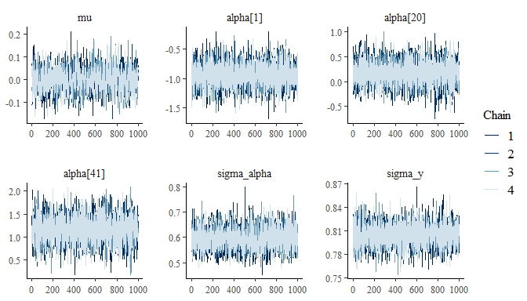

```r
# extract the posterior for a few parameters from the fitted model
posterior_sample_1 <- as.array(fit_ml_lm,
                               pars = c("mu", "alpha[1]", "alpha[20]",
                                        "alpha[41]", "sigma_alpha",
                                        "sigma_y"))

mcmc_trace(posterior_sample_1)
```

Due to the varying intercept we have estimated so many alpha parameters (one for each county) that inspecting the traceplot for all of them becomes impractical. Hence, we only select a few of them.

The traceplots look good for the parameters we have selected for inspection. All chains mix well and explore the same region of parameters values. In addition, we can already see that $mu$ converged around 0, the $\alpha$’s for different counties indicate substantive variation, which is also indicated by the value that the chains for $\sigma_\alpha$ converged on. Recalling the fitted model from “Frequentist Multilevel Modeling in R I” we see that the estimated parameter values are very similar.

##### Examining Split $\hat{R}$

The Split $\hat{R}$ potential scale reduction statistic provides an alternative to visually inspecting traceplots of all parameters for diagnosing convergence. It measures the ratio of the average variance of draws within each randomly initalized chain to the variance of the pooled draws across chains. If all chains converge to the same equilibrium behavior, these will be the same and Rhat will be 1. A Split $\hat{R}$ above 1.1 indicates problems with the fit.

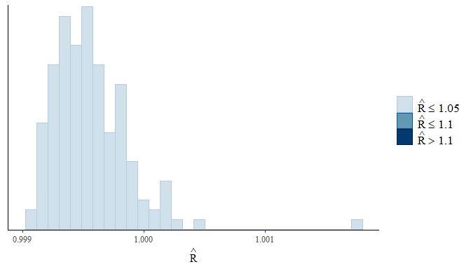

```r
# extract the split Rhat value for each parameter
rhats <- rhat(fit_ml_lm)

# plot the distribution of the split Rhat values
mcmc_rhat_hist(rhats)
```

This diagnostic does also look good, Split $\hat{R}$ is 1 or very close to 1 for all parameters.

##### Examining $n_{eff}$

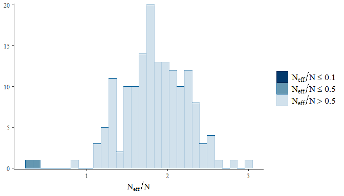

```r
# extract estimates of neff for each parameter
neffs <- neff_ratio(fit_ml_lm)

# plot the distribution of neff values
mcmc_neff_hist(neffs)
```

```r
# any neff values below 0.1
which(neffs < 0.5)
```

```
#>   mu lp__
#>    1  156
```

##### Examining autocorrelation in the chains

In this example $n_{eff}$ is sufficiently large for each parameter. Autocorrelation in the chains usually manifests in small $n_{eff}$ as draws within chains are not independent. As before, we select some parameters as visually inspecting autocorrelation in the chains of all parameters is impractical.

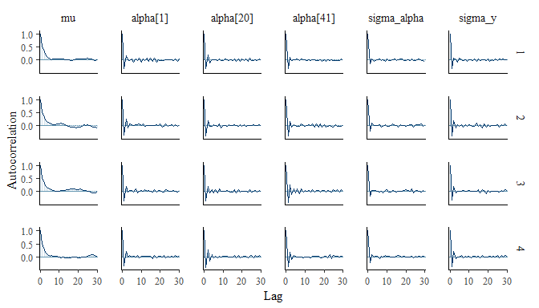

```r
mcmc_acf(posterior_sample_1, lags = 30)
```

As expected given the $n_{eff}$ values, there appears to be no autocorrelation in the chains for most of the parameters. The parameter $\mu$, however, shows slight positive autocorrelation, which means that the chains tends to stay in the same area between iterations. This manifests in $\mu$ being a parameter with an $n_{eff}$ to $N$ ratio smaller than 0.5. This amount of autocorrelation is not severe, after all the $n_{eff}$ to $N$ is still above 0.1, but generally we want to see these autocorrelation plots drop to 0 quickly.

##### Examining sampler diagnostics

A look at Hamiltonian Monte Carlo (sampler) diagnostics concludes the evaluation of model fit. One function call suffices.

```r
check_hmc_diagnostics(fit_ml_lm)
```

```
#>
#> Divergences:
#> 0 of 4000 iterations ended with a divergence.
#>
#> Tree depth:
#> 0 of 4000 iterations saturated the maximum tree depth of 10.
#>
#> Energy:
#> E-BFMI indicated no pathological behavior.
```

This function returns summaries of three important sampler diagnostics, each of which requires its own session to be well explained and understood. In a nutshell:

- Divergent transitions indicate that the sampler did not manage to fully explore the target distribution. This is really, really bad and might mean biased estimates. Divergent transitions can be false positives, too, but you have to check.
- The maximum treedepth is saturated if the sampler has reached the maximum number of steps in one iteration ($2^{10}=1024$ by default) and terminates to avoid long execution time. This is an efficiency problem, i.e., the sampler explores the target distribution but it takes longer and autocorrelation is higher.
- The energy Bayesian fraction of missing information is a rather technical diagnostic that indicates a slow exploration of the target parameter space and larger autocorrelations.

A very convenient tool for quick inspection of these diagnostics is Stan’s ShinyStan interface. Try it.

```r
launch_shinystan(fit_ml_lm)
```

To compare models, check out functions from the `loo` package.

With this model everything looked splendid. Yet, this is more of an exception. A great advantage of Stan is that it alerts you to all kinds of problems where `lme4` would mostly stay silent. See section 5. Further Reading for guidance on how to deal with different warning messages.

## 3. Basic interpretation

We now briefly inspect the posterior summary of a fitted Stan model.

```r
print(fit_ml_lm)
```

```
#> Inference for Stan model: ml_lm.
#> 4 chains, each with iter=2000; warmup=1000; thin=1;
#> post-warmup draws per chain=1000, total post-warmup draws=4000.
#>
#>                mean se_mean   sd    2.5%     25%     50%     75%   97.5%
#> mu             0.00    0.00 0.05   -0.10   -0.04    0.00    0.03    0.10
#> alpha[1]      -0.93    0.00 0.20   -1.33   -1.07   -0.93   -0.80   -0.55
#> alpha[2]      -0.34    0.00 0.17   -0.68   -0.46   -0.34   -0.23    0.00
#> alpha[3]      -0.69    0.00 0.28   -1.23   -0.88   -0.68   -0.50   -0.14
#> alpha[4]      -0.79    0.00 0.19   -1.17   -0.93   -0.79   -0.66   -0.41
#> alpha[5]       0.15    0.00 0.32   -0.48   -0.07    0.15    0.36    0.78
#> alpha[6]       0.61    0.00 0.26    0.09    0.43    0.61    0.79    1.11
#> alpha[7]      -0.39    0.00 0.19   -0.76   -0.52   -0.39   -0.26   -0.01
#> alpha[8]      -0.25    0.00 0.26   -0.75   -0.42   -0.25   -0.09    0.26
#> alpha[9]       0.61    0.00 0.34   -0.06    0.38    0.61    0.84    1.28
#> alpha[10]     -0.60    0.00 0.21   -1.01   -0.74   -0.61   -0.47   -0.20
#> alpha[11]     -0.16    0.00 0.20   -0.57   -0.29   -0.16   -0.02    0.24
#> alpha[12]     -0.27    0.00 0.21   -0.68   -0.41   -0.26   -0.13    0.13
#> alpha[13]     -0.20    0.00 0.28   -0.74   -0.40   -0.20   -0.02    0.36
#> alpha[14]      0.28    0.00 0.28   -0.28    0.09    0.28    0.47    0.85
#> alpha[15]      0.78    0.00 0.24    0.30    0.62    0.78    0.95    1.27
#> alpha[16]      0.51    0.00 0.21    0.11    0.37    0.51    0.65    0.92
#> alpha[17]      0.13    0.00 0.17   -0.20    0.02    0.13    0.25    0.46
#> alpha[18]      0.55    0.00 0.20    0.15    0.42    0.55    0.69    0.95
#> alpha[19]      0.76    0.00 0.21    0.35    0.61    0.76    0.90    1.16
#> alpha[20]      0.18    0.00 0.23   -0.28    0.02    0.19    0.34    0.62
#> alpha[21]     -0.32    0.00 0.24   -0.78   -0.48   -0.32   -0.15    0.14
#> alpha[22]      1.05    0.00 0.22    0.62    0.90    1.05    1.19    1.48
#> alpha[23]      1.30    0.00 0.21    0.89    1.16    1.30    1.45    1.73
#> alpha[24]      0.64    0.00 0.31    0.04    0.44    0.64    0.85    1.25
#> alpha[25]      0.42    0.00 0.19    0.06    0.30    0.42    0.55    0.80
#> alpha[26]      0.72    0.00 0.25    0.23    0.55    0.71    0.88    1.20
#> alpha[27]     -0.39    0.00 0.27   -0.93   -0.56   -0.39   -0.21    0.12
#> alpha[28]     -0.03    0.00 0.33   -0.67   -0.26   -0.04    0.20    0.63
#> alpha[29]      0.37    0.00 0.12    0.14    0.29    0.37    0.45    0.60
#> alpha[30]     -0.27    0.00 0.23   -0.73   -0.43   -0.27   -0.13    0.20
#> alpha[31]      0.18    0.00 0.26   -0.34   -0.01    0.18    0.36    0.68
#> alpha[32]     -0.59    0.00 0.21   -0.99   -0.72   -0.59   -0.44   -0.19
#> alpha[33]     -0.36    0.00 0.17   -0.68   -0.47   -0.36   -0.25   -0.03
#> alpha[34]     -0.35    0.00 0.15   -0.65   -0.45   -0.35   -0.24   -0.05
```

[output cut: 268 more lines]

```
#> alpha[146]   9356    1
#> alpha[147]   7899    1
#> alpha[148]   7987    1
#> alpha[149]   8622    1
#> alpha[150]   9309    1
#> alpha[151]   5873    1
#> alpha[152]   8588    1
#> sigma_alpha  5166    1
#> sigma_y      8376    1
#> lp__         1382    1
#>
#> Samples were drawn using NUTS(diag_e) at Mon Jun 10 18:59:01 2019.
#> For each parameter, n_eff is a crude measure of effective sample size,
#> and Rhat is the potential scale reduction factor on split chains (at
#> convergence, Rhat=1).
```

This summary looks a bit different from what we get using `lme4` but in a way it is much easier to comprehend. On the top and bottom basic information about the model is shown. The rest of the summary lists the estimated parameters as specified in the Stan model. As the model includes a varying intercept over counties, the fitted model returns so many parameters that the output is truncated. Using `fit_ml_lm@model_pars` lets us know the remaining parameters. Here $\mu$ describes the population intercept and the $\alpha$’s the county-specific deviations from this intercept, just as with `fixef()` and `ranef()` in `lme4`. Note, however, that this interpretation is not automatic in Stan but encoded in the model, if we alter the parameterization this interpretation in terms of deviations from a global intercept can change. The posterior estimates itself are shown in the ‘mean’ column, which shows the posterior means. Bayesian as opposed to frequentist analysis does not return a point estimate but a posterior distribution for every parameter - a consequence of the sampler exploring the parameter space and the reason for discarding the warm-up iterations where the chains are still in the process of converging. Accordingly, the column ‘se_mean’ is not the standard error in a frequentist sense, it is the Monte Carlo standard error, which estimates the error in estimating the posterior mean. The uncertainty of the estimates is rather encoded in the posterior standard deviation and quantiles shown in the summary output. The $n_{eff}$ and Split $\hat{R}$ diagnostics are also shown.

If we want more information, we can also extract and plot the posterior of a parameter.

```r
posterior_konstanz <- as.data.frame(fit_ml_lm, pars=c('alpha[2]'))
dim(posterior_konstanz)
```

```
#> [1] 4000    1
```

```r
colnames(posterior_konstanz)
```

```
#> [1] "alpha[2]"
```

`as.data.frame` extracts the posterior from the fitted model and returns it as a data frame with columns reserved for parameters and rows representing the separate iterations/draws from the posterior over all chains. The `pars` argument allows to specify specific parameters of interest. Omitting this argument results in a data frame with posterior of all parameters.

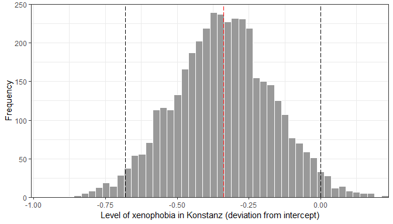

```r
# plot of the posterior of ... using ggplot2
ggplot() +
  geom_histogram(data = posterior_konstanz, aes(x = `alpha[2]`), bins = 50,
                 colour = "white", fill = "gray60") +
  geom_vline(data = posterior_konstanz, aes(xintercept = median(`alpha[2]`)),
             color = "red", linetype = "longdash") +
  geom_vline(data = posterior_konstanz, aes(xintercept = quantile(`alpha[2]`, 0.025)),
             color = "black", linetype = "longdash") +
  geom_vline(data = posterior_konstanz, aes(xintercept = quantile(`alpha[2]`, 0.975)),
             color = "black", linetype = "longdash") +
  theme_bw() +
  labs(x = "Level of xenophobia in Konstanz (deviation from intercept)",
       y = "Frequency") +
  scale_y_continuous(limits = c(0, 250), expand = c(0, 0)) +
  scale_x_continuous(expand = c(0, 0))
```

Using the posterior means/medians we can build simple linear predictions as before in “Frequentist multilevel modeling I and II”. Doing the same thing not only for the medians but for the whole posterior, draw by draw, additionally gives us credible intervals around these predictions. We will learn an intuitive approach to compute, interpret, and visually communicate intervals for frequentist and Bayesian estimates in the next two sessions.

## 4. More examples

Here are two more complicated examples of Stan models, a linear model with varying intercepts for counties nested in states and one individual-level predictor (previously `lm_3`) and a logit model with varying intercepts for several variables and one individual-level predictor (previously `glm_3`). For more complicated implementations see section 5. Further reading below. As illustrated below, the advantage of specifying Stan models is that you write them down exactly according to the formal specification.

##### A more complex linear model

Recall the model `lm_3` from ‘Frequentist multilevel modeling in R I’.

$y_i \sim$ N$(\mu + \alpha_{jk} + \beta x_i , \sigma^2_y)$, for $i = 1, ..., n$  
$\alpha_{jk} \sim$ N$(\gamma_k, \sigma^2_\alpha)$ for $j = 1, ..., J$  
$\gamma_k \sim$ N$(0, \sigma^2_\gamma)$ for $k = 1, ..., K$

Again, we first specify the Stan model and write it to a `.stan` file.

```r
ml_lm2 <- "// MULTILEVEL LINEAR MODEL WITH NESTED VARYING INTERCEPTS AND PREDICTOR

// DATA BLOCK
data {
  int<lower=1> N; // number of observations
  int<lower=1> J; // number of lower-level groups, here counties
  int<lower=1> K; // number of upper-level groups, here states
  int<lower=1, upper=J> county[N]; // county for each observation, length N array
  int<lower=1, upper=K> county_in_state[J]; // county within state for county-level observations, length J array
  vector[N] x; // individual-level predictor, length N
  vector[N] y; // outcome, length N vector
}

// PARAMETERS BLOCK
parameters {
  real mu; // population intercept
  real beta; // population slope
  vector[J] alpha; // varying-intercept for counties, length J vector
  vector[K] gamma; // varying-intercept for states, length K vector
  real<lower=0> sigma_gamma; // between-state variance
  real<lower=0> sigma_alpha; // between-county variance
  real<lower=0> sigma_y; // within-group/residual variance
}

// MODEL BLOCK
model {
  // priors
  mu ~ normal(0, 10); // prior on population intercept
  beta ~ normal(0, 10); // prior on population slope
  alpha ~ normal(gamma[county_in_state], sigma_alpha); // prior on varying intercept for counties
  gamma ~ normal(0, sigma_gamma); // prior on varying intercept for states
  sigma_y ~ normal(0, 10); // prior on residual standard deviation
  sigma_alpha ~ normal(0, 10); // hyperprior on county-level standard deviation
  sigma_gamma ~ normal(0, 10); // hyperprior on state-level standard deviation

  // likelihood
  y ~ normal(mu + alpha[county] + beta * x, sigma_y);
}"

write(ml_lm2, "ml_lm2.stan")
```

Next we assemble the data in the appropriate format.

```r
# transform the factor variables "county" and "state" to integers, rstan does not accept factors
xenodat$county_int <- as.integer(xenodat$county)
xenodat$state_int <- as.integer(xenodat$state)

# arrange the data in order of the integer variables county_int and state_int
xenodat <- arrange(xenodat, county_int, state_int)

# create a vector of state_ids for counties
county_in_state <- distinct(xenodat, county_int, .keep_all = TRUE)$state_int

# assemble data in a list as specified in the "data block"
data_ml_lm2 <- list(N = nrow(xenodat),
                    J = length(unique(xenodat$county_int)),
                    K = length(unique(xenodat$state_int)),
                    county = xenodat$county_int,
                    county_in_state = county_in_state,
                    x = as.integer(xenodat$sex),
                    y = xenodat$xenopho)
```

And finally compile and fit the model.

```r
compiled_ml_lm2 <- stan_model(file = "ml_lm2.stan")

fit_ml_lm2 <- sampling(object = compiled_ml_lm2,
                       data = data_ml_lm2,
                       chains = 4,
                       iter = 2000,
                       warmup = 1000,
                       save_warmup = FALSE,
                       sample_file = "fit_ml_lm2_chains")

fit_ml_lm2@model_pars
```

```
#> [1] "mu"          "beta"        "alpha"       "gamma"       "sigma_gamma"
#> [6] "sigma_alpha" "sigma_y"     "lp__"
```

##### A logit model

Recall the model `glm_3` from ‘Frequentist multilevel modeling in R II’.

$y_i \sim$ Bin$(n_i, \pi_i)$  
$\pi_i =$ logit$^{-1}(\mu + \alpha_{j} + \gamma_{k} + \delta_{l} + \zeta_{m} + \beta x_i)$, for $i = 1, ..., n$  
$\alpha_j \sim$ N$(0, \sigma^2_\alpha)$ for $j = 1, ..., J$  
$\gamma_k \sim$ N$(0, \sigma^2_\gamma)$ for $k = 1, ..., K$  
$\delta_l \sim$ N$(0, \sigma^2_\delta)$ for $l = 1, ..., L$  
$\zeta_m \sim$ N$(0, \sigma^2_\zeta)$ for $m = 1, ..., M$

First specify the Stan model and write it to a `.stan file`. Note that the priors here are now normal(0, 5), which is really weakly informative as we are on the logit scale now and none of the variables has really huge values (income for instance is divided by 10,000). In this situation a scale parameter of 5, spanning almost the complete logit scale close to 0 and 1, puts substantial probability mass on all reasonable values.

```r
ml_glm <- "// MULTILEVEL LOGIT MODEL WITH MULTIPLE CROSSED VARYING INTERCEPTS AND PREDICTOR

// DATA BLOCK
data {
  int<lower=1> N; // number of observations
  int<lower=1> J; // number of racial groups
  int<lower=1> K; // number of age groups
  int<lower=1> L; // number of parties
  int<lower=1> M; // number of congressional districts
  int<lower=1, upper=J> race[N]; // race for each observation, length N array
  int<lower=1, upper=K> age[N]; // age for each observation, length N array
  int<lower=1, upper=L> party[N]; // party for each observations, length N array
  int<lower=1, upper=M> congdist[N]; // party for each observations, length N array
  vector[N] x; // individual-level predictor, length N
  int<lower=0,upper=1> y[N]; // outcome, length N vector
}

// PARAMETERS BLOCK
parameters {
  real mu; // population intercept
  real beta; // population slope
  vector[J] alpha; // varying-intercept for race, length J vector
  vector[K] gamma; // varying-intercept for age, length K vector
  vector[L] delta; // varying-intercept for party, length L vector
  vector[M] zeta; // varying-intercept for congdist, length M vector
  real<lower=0> sigma_alpha; // variance between racial groups
  real<lower=0> sigma_gamma; // variance between age groups
  real<lower=0> sigma_delta; // variance between parties
  real<lower=0> sigma_zeta; // variance between congressional districts
}

// MODEL BLOCK
model {
  // priors
  mu ~ normal(0, 5); // prior on population intercept
  beta ~ normal(0, 5); // prior on population slope
  alpha ~ normal(0, sigma_alpha); // prior on varying intercept for race
  gamma ~ normal(0, sigma_gamma); // prior on varying intercept for age
  delta ~ normal(0, sigma_delta); // prior on varying intercept for party
  zeta ~ normal(0, sigma_zeta); // prior on varying intercept for congdist
  sigma_alpha ~ normal(0, 5); // hyperprior on race-level standard deviation
  sigma_gamma ~ normal(0, 5); // hyperprior on age-level standard deviation
  sigma_delta ~ normal(0, 5); // hyperprior on party-level standard deviation
  sigma_zeta ~ normal(0, 5); // hyperprior on congdist-level standard deviation

  // likelihood
  y ~ bernoulli_logit(mu + alpha[race] + gamma[age] + delta[party] + zeta[congdist] + beta * x);
}"

write(ml_glm, "ml_glm.stan")
```

Then assemble the data in the appropriate format.

```r
# transform the factor variables "race", "age", "party", "congdist" to integers, rstan does not accept factors
voterdat$race_int <- as.integer(voterdat$race)
voterdat$age_int <- as.integer(voterdat$age)
voterdat$party_int <- as.integer(voterdat$party)
voterdat$congdist_int <- as.integer(voterdat$congdist)

# arrange the data in order of the integer variables county_int and state_int
voterdat <- arrange(voterdat, race_int, age_int, party_int, congdist_int)

# assemble data in a list as specified in the "data block"
data_ml_glm <- list(N = nrow(voterdat),
                    J = length(unique(voterdat$race_int)),
                    K = length(unique(voterdat$age_int)),
                    L = length(unique(voterdat$party_int)),
                    M = length(unique(voterdat$congdist_int)),
                    race = voterdat$race_int,
                    age = voterdat$age_int,
                    party = voterdat$party_int,
                    congdist = voterdat$congdist_int,
                    x = voterdat$income,
                    y = as.integer(voterdat$vote2018))
```

Finally compile and fit the model.

```r
compiled_ml_glm <- stan_model(file = "ml_glm.stan")

fit_ml_glm <- sampling(object = compiled_ml_glm,
                       data = data_ml_glm,
                       chains = 4,
                       iter = 2000,
                       warmup = 1000,
                       save_warmup = FALSE,
                       sample_file = "fit_ml_glm_chains")
fit_ml_glm@model_pars
```

```
#>  [1] "mu"          "beta"        "alpha"       "gamma"       "delta"
#>  [6] "zeta"        "sigma_alpha" "sigma_gamma" "sigma_delta" "sigma_zeta"
#> [11] "lp__"
```

With so many modeled parameters the model already takes quite some time.

## 5. Further reading

- [Sampling algorithms](http://elevanth.org/blog/2017/11/28/build-a-better-markov-chain/)
- [Stan syntax cheat sheet](http://www.sumsar.net/files/posts/2017-bayesian-tutorial-exercises/stan_cheat_sheet2.12.pdf)
- [Stan user guide with example models](https://mc-stan.org/docs/2_19/stan-users-guide/index.html)
- [Stan reference manual](https://mc-stan.org/docs/2_19/reference-manual/index.html)
- [Stan case studies](https://mc-stan.org/users/documentation/case-studies)
- [Prior recommendation](https://github.com/stan-dev/stan/wiki/Prior-Choice-Recommendations)
- [Dealing with warning messages I](https://mc-stan.org/misc/warnings.html)
- [Dealing with warning messages II](https://betanalpha.github.io/assets/case_studies/divergences_and_bias.html)
- [All models from Gelman/Hill 2007 and other textbooks translated to Stan code](https://github.com/stan-dev/example-models)